# Análise de Correlação Canônica de Indicadores Municipais

Autor

Gabriel Cardoso

# 1 📊 Resumo do Projeto: Extensão para Correlação Canônica

Este projeto, originalmente focado na identificação de fatores latentes, expande sua fronteira analítica para investigar a interdependência entre conjuntos distintos de indicadores. Após sintetizar a estrutura dos dados via Análise Fatorial, utiliza-se a **Análise de Correlação Canônica (ACC)** para modelar a relação entre o bloco de variáveis de **Infraestrutura e Porte Econômico** e o bloco de **Desenvolvimento Humano e Bem-Estar**.

O objetivo nesta etapa é determinar como a robustez econômica e física de um município brasileiro prediz e se associa ao seu desempenho social. Essa abordagem permite ir além da redução de dados, focando na força da associação entre diferentes domínios da gestão pública e da realidade municipal.

# 2 Análise de Correlação Canônica (ACC)

A **Análise de Correlação Canônica** é uma técnica estatística multivariada avançada que permite examinar a relação entre dois conjuntos de variáveis simultaneamente. Enquanto a regressão múltipla prevê uma única variável dependente a partir de várias independentes, a ACC identifica a máxima correlação possível entre combinações lineares de dois grupos de variáveis ($X$ e $Y$).

O modelo busca criar pares de **Variáveis Canônicas** ($U$ e $V$), que são pontuações compostas que representam cada conjunto original:

$U_1 = a_{1}X_1 + a_{2}X_2 + \dots + a_{p}X_p$

$V_1 = b_{1}Y_1 + b_{2}Y_2 + \dots + b_{q}Y_q$

Neste contexto:

- $U_k$ e $V_k$: São as variáveis canônicas (ou funções) que maximizam a correlação ($\rho$) entre os dois blocos.
- **Cargas Canônicas**: Indicam a contribuição de cada variável original (como PIB ou IDH) para a sua respectiva função canônica.
- **Autoajuste**: O método garante que cada par sucessivo de variáveis canônicas seja independente (ortogonal) dos pares anteriores, permitindo identificar múltiplas “camadas” de relação entre os dados municipais.

# 3 Conjunto de dados

**Exibir código**

```r
library(tidyverse)
library(readxl)
library(DT)
library(ggcorrplot)
library(corrplot)
library(CCA)
library(CCP)
library(candisc)
library(rio)
library(dplyr)

df <- import("BRAZIL_CITIES.csv")

# Inspecionar o dataset
str(df)
```

```
'data.frame':   5573 obs. of  81 variables:
 $ CITY                  : chr  "Abadia De Goiás" "Abadia Dos Dourados" "Abadiânia" "Abaeté" ...
 $ STATE                 : chr  "GO" "MG" "GO" "MG" ...
 $ CAPITAL               : int  0 0 0 0 0 0 0 0 0 0 ...
 $ IBGE_RES_POP          : int  6876 6704 15757 22690 141100 10496 8316 17064 7764 2653 ...
 $ IBGE_RES_POP_BRAS     : int  6876 6704 15609 22690 141040 10496 8316 17064 7764 2653 ...
 $ IBGE_RES_POP_ESTR     : int  0 0 148 0 60 0 0 0 0 0 ...
 $ IBGE_DU               : int  2137 2328 4655 7694 31061 2791 2572 4332 2499 848 ...
 $ IBGE_DU_URBAN         : int  1546 1481 3233 6667 19057 1251 1193 2379 1877 234 ...
 $ IBGE_DU_RURAL         : int  591 847 1422 1027 12004 1540 1379 1953 622 614 ...
 $ IBGE_POP              : int  5300 4154 10656 18464 82956 4538 3725 8994 5685 724 ...
 $ IBGE_1                : int  69 38 139 176 1354 98 37 167 69 12 ...
 $ IBGE_1-4              : int  318 207 650 856 5567 323 156 733 302 32 ...
 $ IBGE_5-9              : int  438 260 894 1233 7618 421 263 978 370 49 ...
 $ IBGE_10-14            : int  517 351 1087 1539 8905 483 277 927 483 63 ...
```

[output cut: 67 more lines]

Selecionar variáveis de interesse para ser mais dinâmico

**Exibir código**

```r
# 1️⃣ Seleção de variáveis numéricas existentes
variaveis_afe <- c(
  "IBGE_RES_POP_BRAS",   # população
  "AREA",                # área do município
  "GDP",                 # PIB
  "GDP_CAPITA",          # PIB per capita
  "IDHM_Renda",          # renda
  "IDHM_Educacao",       # educação
  "IDHM_Longevidade",    # longevidade
  "Cars",                # carros
  "Motorcycles",         # motos
  "FIXED_PHONES",        # telefones fixos
  "PAY_TV"               # TVs
)

dados_afe <- df %>% dplyr::select(all_of(variaveis_afe))
```

**Exibir código**

```r
# 2️⃣ Converter AREA para numérico (tem vírgula no CSV)
dados_afe$AREA <- as.numeric(gsub(",", "", dados_afe$AREA))

# 3️⃣ Tratar missing
dados_afe <- dados_afe %>% mutate(across(everything(), ~ifelse(is.na(.), mean(., na.rm = TRUE), .)))
```

# 4 Visualizar correlações

**Exibir código**

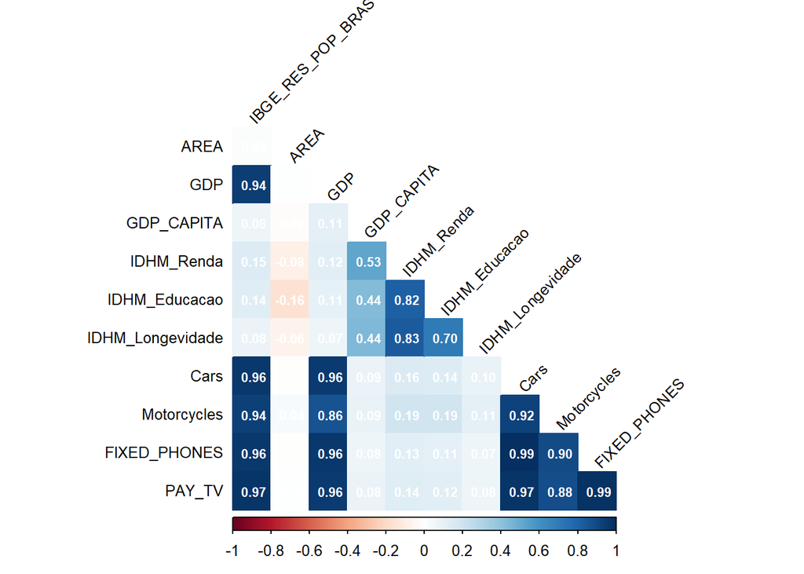

```r
corrplot(cor(dados_afe),
         method = "color",
         type = "lower",        # Exibe apenas a parte inferior
         diag = FALSE,          # Remove a diagonal principal (1.00)
         tl.col = "black",
         tl.cex = 0.8,
         tl.srt = 45,
         addCoef.col = "white",
         number.cex = 0.7)
```

Observe o bloco azul escuro no canto inferior direito e no canto superior esquerdo. Variáveis como **IBGE_RES_POP**, **GDP (PIB)**, **Cars**, **Fixed_Phones** e **Pay_TV** estão quase que perfeitamente correlacionadas ($r \approx 1$).

- **O que isso significa:** Elas estão medindo basicamente a mesma coisa: “tamanho da cidade” ou “riqueza total”.

# 5 Análise de correlação canônica

Preparação dos Conjuntos de Variáveis ($X$ e $Y$)

No R, precisamos separar as colunas em dois objetos distintos para que a função possa calcular a correlação entre as matrizes.

**Exibir código**

```r
# Grupo X: Infraestrutura, Porte e Economia
X <- dados_afe %>%
  dplyr::select(IBGE_RES_POP_BRAS, AREA, GDP, Cars, Motorcycles, FIXED_PHONES, PAY_TV)

# Grupo Y: Bem-estar e Desenvolvimento Humano
Y <- dados_afe %>%
  dplyr::select(GDP_CAPITA, IDHM_Renda, IDHM_Educacao, IDHM_Longevidade)

# Escalonamento (opcional, mas recomendado para facilitar a interpretação das cargas)
X_scale <- scale(X)
Y_scale <- scale(Y)
```

Execução da ACC

**Exibir código**

```r
library(CCA)

# Executando a Análise de Correlação Canônica
res_cca <- cancor(X_scale, Y_scale)

res_cca
```

```
Canonical correlation analysis of:
     7   X  variables:  IBGE_RES_POP_BRAS, AREA, GDP, Cars, Motorcycles, FIXED_PHONES, PAY_TV
  with   4   Y  variables:  GDP_CAPITA, IDHM_Renda, IDHM_Educacao, IDHM_Longevidade

     CanR   CanRSQ    Eigen percent    cum                          scree
1 0.36043 0.129908 0.149304  71.200  71.20 ******************************
2 0.18642 0.034754 0.036005  17.170  88.37 *******
3 0.12698 0.016124 0.016388   7.815  96.19 ***
4 0.08907 0.007934 0.007998   3.814 100.00 **

Test of H0: The canonical correlations in the
current row and all that follow are zero

     CanR LR test stat approx F numDF denDF   Pr(> F)
1 0.36043      0.81975   40.592    28 20056 < 2.2e-16 ***
2 0.18642      0.94215   18.614    18 15735 < 2.2e-16 ***
3 0.12698      0.97607   13.559    10 11128 < 2.2e-16 ***
4 0.08907      0.99207   11.127     4  5565 5.456e-09 ***
---
Signif. codes:  0 '***' 0.001 '**' 0.01 '*' 0.05 '.' 0.1 ' ' 1
```

A análise de variância demonstra que o primeiro par canônico é o principal eixo de conexão entre os domínios, concentrando mais de **71% da variância compartilhada**. Contudo, o coeficiente de determinação ($R^2 = 0.13$) sugere que o ‘porte’ das cidades brasileiras explica apenas uma fatia moderada dos indicadores de bem-estar social, deixando margem para a influência de fatores locais, geográficos ou políticos que não estão contidos apenas no volume econômico bruto.

# 6 Coeficientes canônicos

**Exibir código**

```r
coef(res_cca, type = "both", standardize = T)
```

```
[[1]]
                       Xcan1      Xcan2      Xcan3      Xcan4
IBGE_RES_POP_BRAS  0.9536212 -2.4666771  0.4144881 -0.5677417
AREA               0.4564053  0.2390038 -0.7552589  0.2287733
GDP                0.6888924  2.9599830  2.0312481  0.6714384
Cars              -3.7394499  2.7793739 -3.9337311 -7.4170619
Motorcycles       -1.3536422  0.2355177  0.5872214  2.0872291
FIXED_PHONES       5.4973930 -4.9581307  2.4832851  4.8992809
PAY_TV            -2.5430307  1.7917519 -1.7379962  0.9078366

[[2]]
                      Ycan1       Ycan2       Ycan3      Ycan4
GDP_CAPITA        0.2096038  1.05633927  0.44888372  0.1453101
IDHM_Renda       -0.6759863  0.02165778 -1.74952951  1.3784153
IDHM_Educacao    -0.8070412 -0.45595291  1.46905308 -0.2081700
IDHM_Longevidade  0.4641156  0.17624370 -0.08107636 -1.7446525
```

Os coeficientes canônicos padronizados revelam que a relação entre os blocos é construída de forma complexa. No domínio da infraestrutura, a **Telefonia Fixa** e a **Frota de Veículos** são os indicadores com maior peso relativo para maximizar a correlação com o bloco social. No domínio do desenvolvimento humano, a **Educação** e a **Renda** consolidam-se como os principais componentes da variável canônica social, demonstrando que esses dois indicadores são os que melhor captam a influência exercida pela estrutura econômica e física do município.